# UQoL Indicators in Barcelona 2026 - PCA

# 2. Data preprocessing

Because of the data format, a series of transformations are necessary to prepare them for analysis.

## 2.1 Transform type

The satisfaction variable is renamed to a standardised label for consistency across the analysis.

```r
names(indicators_raw)[names(indicators_raw) == "Satisfacción_Barrio"] <- "satisfaction"
```

The full list of column names is printed to verify the structure of the dataset.

```r
colnames(indicators_raw)
```

```
##  [1] "codi_districte"
##  [2] "nom_districte"
##  [3] "codi_barri"
##  [4] "nom_barri"
##  [5] "Barrio.turístico.en.2023"
##  [6] "X805_Eco_Individual.income"
##  [7] "X852_Eco_Individual.income"
##  [8] "X582_Eco_Occupation"
##  [9] "X822_Eco_Occupation"
## [10] "X1014_Eco_Occupation"
## [11] "X283_Eco_Occupation"
## [12] "X43_Eco_Tourism.development"
## [13] "X279_Eco_"
## [14] "X523_Eco_"
## [15] "X671_Inf_Education"
```

[output cut: 37 more lines]

All indicator columns are converted to numeric format to allow aggregation and work. In the original data, decimal values are recorded with a comma separator. These are replaced with a decimal point to allow calculations. Also, whitespace is also removed. This step is required before any calculations can be performed.

```r
# Replace commas with decimal points and remove whitespace in all relevant columns
cols_to_convert <- c("X805_Eco_Individual.income", "X852_Eco_Individual.income","X582_Eco_Occupation",
"X822_Eco_Occupation","X1014_Eco_Occupation","X283_Eco_Occupation",
"X43_Eco_Tourism.development", "X279_Eco_", "X523_Eco_", "X671_Inf_Education", "X809_Inf_Education","X744_Inf_Education", "X974_Inf_Education",
"X10_Healthcare", "X642_Healthcare", "X257_Healthcare", "X902_Healthcare", "X148_Housing", "X465_Housing", "X674_Housing", "X477_Housing", "X139_Housing","X866_Housing", "X653_Housing", "X569_Inf_Leisure.and.cultural.activities",
"X198_Inf_Leisure.and.cultural.activities", "X479_Inf_Noise", "X1041_Inf_Security.and.safety",
"X30_Inf_Water.consumption", "X989_Mob_", "X361_Mob_", "X515_Mob_",
"X9_Soc_Cultural.diversity.and.identity", "X329_Soc_Cultural.diversity.and.identity",
"X670_Soc_Cultural.diversity.and.identity", "X123_Soc_Demographics", "X589_Soc_Density.of.social.relations", "X331_Soc_Equality.and.diversity",
"X799_Soc_Public.participation.and.trust.in.institutions", "X565_Soc_Social.participation",
"X348_Urb_Population.density", "X265_Urb_", "X534_Urb_", "X877_Urb_Air.quality",
"X484_Urb_Nature.based.assets", "X633_Urb_Nature.based.assets", "satisfaction")

# Apply transformation to all columns in a loop
for (col in cols_to_convert) {
  indicators_raw[[col]] <- gsub(",", ".", indicators_raw[[col]])
  # Remove whitespaces
 indicators_raw[[col]] <- gsub("\\s+", "", indicators_raw[[col]])
  #Convert to numerical
  indicators_raw[[col]] <- as.numeric(indicators_raw[[col]])
}

# Verify conversion
summary(indicators_raw[cols_to_convert])
```

```
##  X805_Eco_Individual.income X852_Eco_Individual.income X582_Eco_Occupation
##  Min.   :10929              Min.   : 3.60              Min.   :41.20
##  1st Qu.:16978              1st Qu.: 9.00              1st Qu.:60.80
##  Median :20122              Median :12.00              Median :65.30
##  Mean   :20616              Mean   :12.96              Mean   :63.14
##  3rd Qu.:23437              3rd Qu.:14.60              3rd Qu.:66.90
##  Max.   :37800              Max.   :39.30              Max.   :70.00
##  X822_Eco_Occupation X1014_Eco_Occupation X283_Eco_Occupation
##  Min.   : 1.800      Min.   :  11.75      Min.   :46.77
##  1st Qu.: 4.500      1st Qu.: 183.44      1st Qu.:53.29
##  Median : 7.500      Median : 325.31      Median :55.56
##  Mean   : 9.151      Mean   : 355.26      Mean   :55.07
##  3rd Qu.:11.900      3rd Qu.: 521.51      3rd Qu.:56.74
##  Max.   :25.600      Max.   :1159.45      Max.   :59.49
##  X43_Eco_Tourism.development   X279_Eco_        X523_Eco_    X671_Inf_Education
##  Min.   :   0.0              Min.   : 0.820   Min.   :  13   Min.   :50.87
##  1st Qu.:   3.0              1st Qu.: 1.930   1st Qu.: 200   1st Qu.:64.32
##  Median :  32.0              Median : 2.840   Median : 624   Median :71.92
##  Mean   : 134.5              Mean   : 3.167   Mean   : 807   Mean   :69.77
##  3rd Qu.: 171.0              3rd Qu.: 3.810   3rd Qu.:1060   3rd Qu.:75.91
##  Max.   :1655.0              Max.   :12.590   Max.   :3628   Max.   :82.42
##  X809_Inf_Education X744_Inf_Education X974_Inf_Education X10_Healthcare
##  Min.   : 3.70      Min.   :     0     Min.   : 4.20      Min.   :77.94
##  1st Qu.:10.50      1st Qu.:     0     1st Qu.:11.40      1st Qu.:83.95
##  Median :13.40      Median : 22944     Median :15.20      Median :84.88
##  Mean   :13.89      Mean   : 76987     Mean   :19.32      Mean   :84.38
##  3rd Qu.:18.80      3rd Qu.:110876     3rd Qu.:25.20      3rd Qu.:85.36
##  Max.   :24.30      Max.   :648319     Max.   :48.20      Max.   :87.62
##  X642_Healthcare  X257_Healthcare X902_Healthcare   X148_Housing
##  Min.   : 0.000   Min.   : 0.00   Min.   : 0.600   Min.   : 28.19
##  1st Qu.: 0.000   1st Qu.: 7.00   1st Qu.: 2.300   1st Qu.: 51.32
##  Median : 1.000   Median :13.00   Median : 3.100   Median : 54.49
##  Mean   : 1.918   Mean   :15.53   Mean   : 3.677   Mean   : 58.76
##  3rd Qu.: 3.000   3rd Qu.:20.00   3rd Qu.: 4.400   3rd Qu.: 62.56
##  Max.   :10.000   Max.   :63.00   Max.   :10.300   Max.   :124.08
##   X465_Housing    X674_Housing    X477_Housing     X139_Housing
##  Min.   :36.79   Min.   : 0.00   Min.   : 52.00   Min.   :2.050
##  1st Qu.:58.99   1st Qu.:13.61   1st Qu.: 64.09   1st Qu.:2.390
##  Median :63.81   Median :15.46   Median : 68.81   Median :2.440
##  Mean   :61.94   Mean   :14.80   Mean   : 70.89   Mean   :2.486
```

[output cut: 64 more lines]

```
##  Max.   :360.00                Max.   :1384.64             Max.   :4833
##    X534_Urb_     X877_Urb_Air.quality X484_Urb_Nature.based.assets
##  Min.   :17.15   Min.   :  258        Min.   : 0.000
##  1st Qu.:44.75   1st Qu.: 3298        1st Qu.: 0.000
##  Median :51.67   Median : 5811        Median : 0.540
##  Mean   :51.23   Mean   : 6648        Mean   : 2.739
##  3rd Qu.:58.99   3rd Qu.: 9106        3rd Qu.: 2.980
##  Max.   :83.92   Max.   :22013        Max.   :28.920
##  X633_Urb_Nature.based.assets  satisfaction
##  Min.   : 0.0000              Min.   :5.830
##  1st Qu.: 0.1500              1st Qu.:7.290
##  Median : 0.4600              Median :7.720
##  Mean   : 0.9248              Mean   :7.599
##  3rd Qu.: 0.9400              3rd Qu.:7.910
##  Max.   :14.5400              Max.   :8.670
```

## 2.2 Polarity revision

Each indicator has a defined polarity: positive indicators increase in value as the UQoL dimension improves; negative indicators decrease. To ensure all indicators point in the same direction, such as higher values meaning better conditions, the sign of negative indicators is multiplied by −1. The function below defines which indicators require inversion. The polarity indications are the result of expert consultation.

```r
# Function to invert signs of negative indicators
invert_negative_indicators <- function(df) {
  columns_to_invert <- c(
    "X822_Eco_Occupation",
    "X1014_Eco_Occupation",
    "X283_Eco_Occupation",
    "X43_Eco_Tourism.development",
    "X674_Housing",
    "X866_Housing",
    "X139_Housing",
    "X809_Inf_Education",
    "X974_Inf_Education",
    "X361_Mob_",
    "X989_Mob_",
    "X799_Soc_Public.participation.and.trust.in.institutions",
    "X479_Inf_Noise",
    "X348_Urb_Population.density"
  )

  for (col in columns_to_invert) {
    if (col %in% colnames(df)) {
      df[[col]] <- -1 * df[[col]]
    }
  }

  return(df)
}
```

The function is applied to the full dataset, producing a new object in which all negative indicators have been inverted.

```r
inverted_indicators <- invert_negative_indicators(indicators_raw)
```

```r
neutral_indicators <- c(
  "X852_Eco_Individual.income",
  "X148_Housing",
  "X30_Inf_Water.consumption",
  "X9_Soc_Cultural.diversity.and.identity",
  "X670_Soc_Cultural.diversity.and.identity",
  "X123_Soc_Demographics",
  "X589_Soc_Density.of.social.relations",
  "X331_Soc_Equality.and.diversity"
)
#Save the new dataset without the neutral indicators so they don't affect results
inverted_indicators <- inverted_indicators[,
  !colnames(inverted_indicators) %in% neutral_indicators
]
```

## 2.3 Plotting format setting

The colour scheme used in all correlation matrices and Scree plots is defined here centrally for consistency.

```r
colors = c("#8C4D59", "#D3D1C7", "#2C4019")
```

```r
col = "#8C4D59"   # For highlighted PC points and lines
```

# 3. PCA

For each UQoL dimension, the following sequence is applied:

1. a subset of the relevant indicators is extracted.
2. a correlation matrix is computed and visualised to check for multicollinearity.
3. a Principal Component Analysis (PCA) is run.
4. the variance explained by each component is calculated and displayed as a Scree plot.
5. indicator weights are derived from the component loadings and normalised to sum to one.

## 3.1 Urban environment dimension

```r
urban_indicators <- inverted_indicators[, c("X348_Urb_Population.density",
"X265_Urb_",
"X534_Urb_" ,
"X479_Inf_Noise",
"X877_Urb_Air.quality",
"X484_Urb_Nature.based.assets",
"X633_Urb_Nature.based.assets"
)]

summary(urban_indicators)
```

```
##  X348_Urb_Population.density   X265_Urb_      X534_Urb_     X479_Inf_Noise
##  Min.   :-1384.64            Min.   :  45   Min.   :17.15   Min.   :-92.51
##  1st Qu.: -905.99            1st Qu.: 649   1st Qu.:44.75   1st Qu.:-77.48
##  Median : -728.60            Median :1008   Median :51.67   Median :-71.10
##  Mean   : -700.22            Mean   :1330   Mean   :51.23   Mean   :-71.74
##  3rd Qu.: -564.00            3rd Qu.:1971   3rd Qu.:58.99   3rd Qu.:-64.47
##  Max.   :  -19.67            Max.   :4833   Max.   :83.92   Max.   :-45.30
##  X877_Urb_Air.quality X484_Urb_Nature.based.assets X633_Urb_Nature.based.assets
##  Min.   :  258        Min.   : 0.000               Min.   : 0.0000
##  1st Qu.: 3298        1st Qu.: 0.000               1st Qu.: 0.1500
##  Median : 5811        Median : 0.540               Median : 0.4600
##  Mean   : 6648        Mean   : 2.739               Mean   : 0.9248
##  3rd Qu.: 9106        3rd Qu.: 2.980               3rd Qu.: 0.9400
##  Max.   :22013        Max.   :28.920               Max.   :14.5400
```

```r
cor_matrix_urban <- cor(urban_indicators)
print(cor_matrix_urban)
```

```
##                              X348_Urb_Population.density    X265_Urb_
## X348_Urb_Population.density                  1.000000000 -0.008067398
## X265_Urb_                                   -0.008067398  1.000000000
## X534_Urb_                                   -0.103835093  0.331063916
## X479_Inf_Noise                              -0.095785689  0.360430319
## X877_Urb_Air.quality                        -0.094673549  0.753508304
## X484_Urb_Nature.based.assets                -0.030176198 -0.129497976
## X633_Urb_Nature.based.assets                -0.092690788  0.014601264
##                                X534_Urb_ X479_Inf_Noise X877_Urb_Air.quality
## X348_Urb_Population.density  -0.10383509    -0.09578569         -0.094673549
## X265_Urb_                     0.33106392     0.36043032          0.753508304
## X534_Urb_                     1.00000000     0.08237983          0.435731491
## X479_Inf_Noise                0.08237983     1.00000000          0.064249521
## X877_Urb_Air.quality          0.43573149     0.06424952          1.000000000
## X484_Urb_Nature.based.assets -0.27678944     0.02803560         -0.059317528
## X633_Urb_Nature.based.assets -0.16425104     0.09019981          0.009809078
##                              X484_Urb_Nature.based.assets
## X348_Urb_Population.density                   -0.03017620
## X265_Urb_                                     -0.12949798
## X534_Urb_                                     -0.27678944
## X479_Inf_Noise                                 0.02803560
## X877_Urb_Air.quality                          -0.05931753
## X484_Urb_Nature.based.assets                   1.00000000
## X633_Urb_Nature.based.assets                   0.13737878
##                              X633_Urb_Nature.based.assets
## X348_Urb_Population.density                  -0.092690788
## X265_Urb_                                     0.014601264
## X534_Urb_                                    -0.164251038
## X479_Inf_Noise                                0.090199807
## X877_Urb_Air.quality                          0.009809078
## X484_Urb_Nature.based.assets                  0.137378776
## X633_Urb_Nature.based.assets                  1.000000000
```

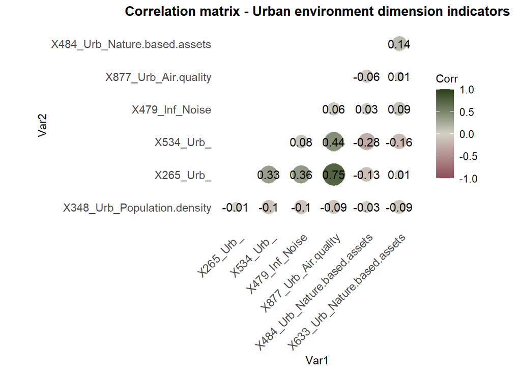

```r
ggcorrplot(cor_matrix_urban,
           method = "circle",
           type = "lower",

           lab = TRUE,
           colors = colors,
           title = "Correlation matrix - Urban environment dimension indicators") +
  theme_minimal(base_family = "Verdana") +
  theme(text = element_text(family = "Verdana")) +
  theme(axis.text = element_text(size = 11),
        axis.title = element_text(size = 11),
        plot.title = element_text(size = 13, face = "bold", hjust = 0.5, lineheight = 1.2),
        legend.text = element_text(size = 10),
        legend.title = element_text(size = 11)) +
  theme(axis.text.x = element_text(angle = 45, hjust = 1)) +
  theme(panel.grid = element_blank())
```

```r
ggsave(here("1_PCA", "Results", "Urban", "heatmap_correlations_urban.png"),
       plot = last_plot(), width = 10, height = 8, dpi = 300)
```

### 3.1.1 Urban Environment PCA

```r
urban_dim_results <- prcomp(urban_indicators, scale = TRUE)

urban_dim_results$rotation
```

```
##                                      PC1         PC2         PC3         PC4
## X348_Urb_Population.density   0.10116885  0.28278557  0.89511333  0.04991505
## X265_Urb_                    -0.59089706 -0.16072626  0.26689205 -0.02148401
## X534_Urb_                    -0.45658327  0.29762986 -0.25190331 -0.03237581
## X479_Inf_Noise               -0.24316236 -0.42574678  0.09288351  0.79741811
## X877_Urb_Air.quality         -0.57585253 -0.06724112  0.11201688 -0.42644781
## X484_Urb_Nature.based.assets  0.19776785 -0.51232939  0.20519805 -0.38242491
## X633_Urb_Nature.based.assets  0.04786503 -0.59778991 -0.02835673 -0.17893167
##                                       PC5        PC6         PC7
## X348_Urb_Population.density   0.185696016  0.2565386 -0.07604438
## X265_Urb_                    -0.006056895 -0.3123735  0.67505625
## X534_Urb_                    -0.014650507  0.7875632  0.13406846
## X479_Inf_Noise               -0.164375524  0.1251676 -0.26911434
## X877_Urb_Air.quality         -0.033478759 -0.1782822 -0.66072808
## X484_Urb_Nature.based.assets -0.625349346  0.3287833  0.10436079
## X633_Urb_Nature.based.assets  0.738961245  0.2465870  0.02581981
```

```r
write.csv(urban_dim_results$rotation,
          file = here("1_PCA", "Results", "Urban", "urban_pca.csv"),
          row.names = TRUE)
```

```r
var_exp_urban_dim <- urban_dim_results$sdev^2 / sum(urban_dim_results$sdev^2)

var_exp_urban_dim * 100
```

```
## [1] 31.171392 18.751915 14.300679 13.041486 12.043974  8.319189  2.371366
```

```r
png(here("1_PCA", "Results", "Urban", "scree_plot_pca_urban_dimension.png"),
    width = 800, height = 600, res = 150)

par(family = "Verdana")

plot(var_exp_urban_dim * 100, type = "b", xlab = "Principal Component",
     ylab = "Variance explained (%)", main = "Scree plot PCA Urban Environment dimension",
     col = "black", lwd = 1, pch = 16)

points(1:2, var_exp_urban_dim[1:2] * 100, col = col, pch = 16, cex = 1.5)
lines(1:2, var_exp_urban_dim[1:2] * 100, col = col, lwd = 3)

dev.off()
```

### 3.1.2 Urban environment weight

```r
weight_PC1_urbandim <- abs(urban_dim_results$rotation[, 1])
weight_PC2_urbandim <- abs(urban_dim_results$rotation[, 2])

variance_PC1 <- var_exp_urban_dim[1]
variance_PC2 <- var_exp_urban_dim[2]

combined_weight_urbandim <- (weight_PC1_urbandim * variance_PC1 +
                                weight_PC2_urbandim * variance_PC2)

normalised_combined_weight_urbandim <- combined_weight_urbandim / sum(combined_weight_urbandim)

normalised_combined_weight_urbandim
```

```
##  X348_Urb_Population.density                    X265_Urb_
##                   0.07486757                   0.18975543
##                    X534_Urb_               X479_Inf_Noise
##                   0.17541693                   0.13778822
##         X877_Urb_Air.quality X484_Urb_Nature.based.assets
##                   0.17008327                   0.13963487
## X633_Urb_Nature.based.assets
##                   0.11245370
```

```r
write.csv(normalised_combined_weight_urbandim,
          file = here("1_PCA", "Results", "Urban", "urban_weight.csv"),
          row.names = TRUE)
```

## 3.2 Economic Dimension

```r
  economic_indicators <- inverted_indicators[, c( "X805_Eco_Individual.income",
"X582_Eco_Occupation","X822_Eco_Occupation",
"X1014_Eco_Occupation","X283_Eco_Occupation",
"X43_Eco_Tourism.development",
"X279_Eco_","X523_Eco_"
)]

summary(economic_indicators)
```

```
##  X805_Eco_Individual.income X582_Eco_Occupation X822_Eco_Occupation
##  Min.   :10929              Min.   :41.20       Min.   :-25.600
##  1st Qu.:16978              1st Qu.:60.80       1st Qu.:-11.900
##  Median :20122              Median :65.30       Median : -7.500
##  Mean   :20616              Mean   :63.14       Mean   : -9.151
##  3rd Qu.:23437              3rd Qu.:66.90       3rd Qu.: -4.500
##  Max.   :37800              Max.   :70.00       Max.   : -1.800
##  X1014_Eco_Occupation X283_Eco_Occupation X43_Eco_Tourism.development
##  Min.   :-1159.45     Min.   :-59.49      Min.   :-1655.0
##  1st Qu.: -521.51     1st Qu.:-56.74      1st Qu.: -171.0
##  Median : -325.31     Median :-55.56      Median :  -32.0
##  Mean   : -355.26     Mean   :-55.07      Mean   : -134.5
##  3rd Qu.: -183.44     3rd Qu.:-53.29      3rd Qu.:   -3.0
##  Max.   :  -11.75     Max.   :-46.77      Max.   :    0.0
##    X279_Eco_        X523_Eco_
##  Min.   : 0.820   Min.   :  13
##  1st Qu.: 1.930   1st Qu.: 200
##  Median : 2.840   Median : 624
##  Mean   : 3.167   Mean   : 807
##  3rd Qu.: 3.810   3rd Qu.:1060
##  Max.   :12.590   Max.   :3628
```

A correlation matrix is computed to examine the pairwise relationships between indicators before running the PCA.

```r
cor_matrix_economic <- cor(economic_indicators)
print(cor_matrix_economic)
```

```
##                             X805_Eco_Individual.income X582_Eco_Occupation
## X805_Eco_Individual.income                   1.0000000          0.58813267
## X582_Eco_Occupation                          0.5881327          1.00000000
## X822_Eco_Occupation                          0.8566910          0.70740661
## X1014_Eco_Occupation                         0.1370485         -0.02550584
## X283_Eco_Occupation                          0.2416702         -0.09843467
## X43_Eco_Tourism.development                 -0.2711167         -0.07846059
## X279_Eco_                                    0.1974709         -0.15989950
## X523_Eco_                                    0.3354267          0.09683509
##                             X822_Eco_Occupation X1014_Eco_Occupation
## X805_Eco_Individual.income           0.85669101           0.13704851
## X582_Eco_Occupation                  0.70740661          -0.02550584
## X822_Eco_Occupation                  1.00000000          -0.05428216
## X1014_Eco_Occupation                -0.05428216           1.00000000
## X283_Eco_Occupation                  0.34535283           0.11497176
## X43_Eco_Tourism.development         -0.34274425           0.32345229
## X279_Eco_                            0.25395450          -0.17542619
## X523_Eco_                            0.41204898          -0.60826869
##                             X283_Eco_Occupation X43_Eco_Tourism.development
## X805_Eco_Individual.income           0.24167016                 -0.27111669
## X582_Eco_Occupation                 -0.09843467                 -0.07846059
## X822_Eco_Occupation                  0.34535283                 -0.34274425
## X1014_Eco_Occupation                 0.11497176                  0.32345229
## X283_Eco_Occupation                  1.00000000                 -0.16910038
## X43_Eco_Tourism.development         -0.16910038                  1.00000000
## X279_Eco_                            0.42353833                 -0.50861097
## X523_Eco_                            0.10996088                 -0.82170861
##                              X279_Eco_   X523_Eco_
## X805_Eco_Individual.income   0.1974709  0.33542670
## X582_Eco_Occupation         -0.1598995  0.09683509
## X822_Eco_Occupation          0.2539545  0.41204898
## X1014_Eco_Occupation        -0.1754262 -0.60826869
## X283_Eco_Occupation          0.4235383  0.10996088
## X43_Eco_Tourism.development -0.5086110 -0.82170861
## X279_Eco_                    1.0000000  0.61407061
## X523_Eco_                    0.6140706  1.00000000
```

The correlation matrix is visualised as a heat map. Positive correlations appear in green, negative in red, and near-zero correlations in off-white.

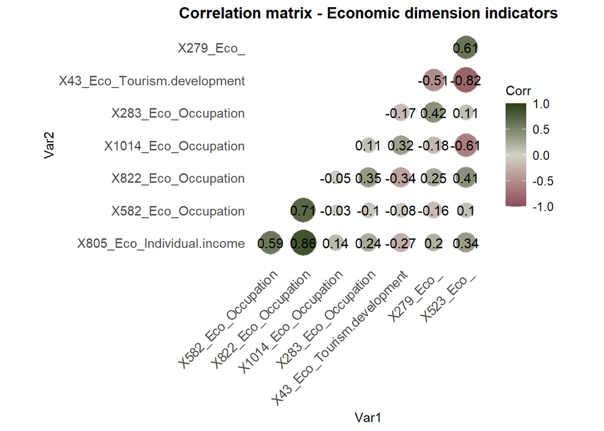

```r
ggcorrplot(cor_matrix_economic,
           method = "circle",
           type = "lower",
           lab = TRUE,
           colors = colors,
           title = "Correlation matrix - Economic dimension indicators") +
  theme_minimal(base_family = "Verdana") +
  theme(text = element_text(family = "Verdana")) +
  theme(axis.text = element_text(size = 11),
        axis.title = element_text(size = 11),
        plot.title = element_text(size = 13, face = "bold", hjust = 0.5, lineheight = 1.2),
        legend.text = element_text(size = 10),
        legend.title = element_text(size = 11)) +
  theme(axis.text.x = element_text(angle = 45, hjust = 1)) +
  theme(panel.grid = element_blank())
```

The plot is saved as a high-resolution PNG file for inclusion in the dissertation result section.

```r
ggsave(here("1_PCA", "Results", "Economic", "heatmap_correlations_economic.png"),
       plot = last_plot(), width = 10, height = 8, dpi = 300)
```

### 3.2.1 Economic PCA

The PCA is computed on the scaled indicator matrix. The rotation matrix shows the contribution of each indicator to each principal component and is also saved to CSV.

```r
#calculate Principal Components
economic_dim_results <- prcomp(economic_indicators, scale = TRUE)

#display Principal Components
economic_dim_results$rotation
```

```
##                                    PC1           PC2          PC3        PC4
## X805_Eco_Individual.income   0.3965416  0.4126022710  0.060500786 -0.1611915
## X582_Eco_Occupation          0.2488569  0.4978798723 -0.353348059  0.1103866
## X822_Eco_Occupation          0.4517984  0.3702925650  0.007078389  0.1564172
## X1014_Eco_Occupation        -0.1889950  0.3806868076  0.489387895 -0.6525972
## X283_Eco_Occupation          0.2092938 -0.0009288178  0.678438110  0.5445091
## X43_Eco_Tourism.development -0.4131577  0.2879160043  0.064528568  0.4312852
## X279_Eco_                    0.3411216 -0.3257886830  0.363582595 -0.1360296
## X523_Eco_                    0.4583852 -0.3328681650 -0.187882093 -0.1023788
##                                     PC5         PC6         PC7         PC8
## X805_Eco_Individual.income  -0.13135643  0.60532821 -0.41637002 -0.29296810
## X582_Eco_Occupation         -0.02869908 -0.64936323 -0.35309251  0.07729969
## X822_Eco_Occupation         -0.03535130  0.05835284  0.79116249  0.06043468
## X1014_Eco_Occupation         0.07742270 -0.14125415  0.04112209  0.35543880
## X283_Eco_Occupation          0.37067141 -0.08512795 -0.21671811  0.08840809
## X43_Eco_Tourism.development -0.59739796  0.20448213 -0.05644925  0.39287461
## X279_Eco_                   -0.69309429 -0.32730982 -0.01038580 -0.19794483
## X523_Eco_                    0.00406881  0.17987759 -0.15514976  0.75951086
```

```r
# Save rotation matrix to CSV
write.csv(economic_dim_results$rotation,
          file = here("1_PCA", "Results", "Economic", "economic_pca.csv"),
          row.names = TRUE)
```

The variance explained by each principal component is calculated by squaring the standard deviations returned by “prcomp”, dividing by their total, and multiplying by 100 to express as a percentage.

```r
# Calculate variance for each Principal Component
var_exp_economic_dim <- economic_dim_results$sdev^2 / sum(economic_dim_results$sdev^2)

# Show variance in percentage
var_exp_economic_dim * 100
```

```
## [1] 40.5935582 24.8590063 16.7474940  7.6186752  4.9356333  3.5876887  0.9540785
## [8]  0.7038658
```

```r
# Open PNG so save graph
png(here("1_PCA", "Results", "Economic", "scree_plot_pca_economic_dimension.png"),
    width = 800, height = 600, res = 150)

par(family = "Verdana")

# Display explained variance
plot(var_exp_economic_dim * 100, type = "b", xlab = "Principal Component",
     ylab = "Variance explained (%)", main = "Scree plot PCA Economic dimension",
     col = "black", lwd = 1, pch = 16)

# Highlight PC1 and PC2
points(1:2, var_exp_economic_dim[1:2] * 100, col = col, pch = 16, cex = 1.5)
lines(1:2, var_exp_economic_dim[1:2] * 100, col = col, lwd = 3)

# Close graph
dev.off()
```

### 3.2.2 Economic weight

```r
weight_PC1_economicdim <- abs(economic_dim_results$rotation[, 1]) # Taking absolute values for PC1
normalised_weight_economicdim<- weight_PC1_economicdim / sum(weight_PC1_economicdim)  # Normalise so that they sum 1
normalised_weight_economicdim
```

```
##  X805_Eco_Individual.income         X582_Eco_Occupation
##                  0.14642527                  0.09189185
##         X822_Eco_Occupation        X1014_Eco_Occupation
##                  0.16682914                  0.06978750
##         X283_Eco_Occupation X43_Eco_Tourism.development
##                  0.07728292                  0.15256085
##                   X279_Eco_                   X523_Eco_
##                  0.12596111                  0.16926136
```

```r
# Calculate combined weights of PC1 and Pc2

# Absolute values for PC1
weight_PC1_economicdim <- abs(economic_dim_results$rotation[, 1])
# Absolute values for PC2
weight_PC2_economicdim <- abs(economic_dim_results$rotation[, 2])

# Ponderated according to explicit variance
variance_PC1 <- var_exp_economic_dim[1]
variance_PC2 <- var_exp_economic_dim[2]

# Calculation of the weighted contribution for each indicator
combined_weight_economicdim <- (weight_PC1_economicdim * variance_PC1 +
                                weight_PC2_economicdim * variance_PC2)

# Normalise weights so they sum 1
normalised_combined_weight_economicdim <- combined_weight_economicdim / sum(combined_weight_economicdim)

# Show normalised weights
normalised_combined_weight_economicdim
```

```
##  X805_Eco_Individual.income         X582_Eco_Occupation
##                  0.15077502                  0.12860477
##         X822_Eco_Occupation        X1014_Eco_Occupation
##                  0.15759058                  0.09803482
##         X283_Eco_Occupation X43_Eco_Tourism.development
##                  0.04873896                  0.13690079
##                   X279_Eco_                   X523_Eco_
##                  0.12555731                  0.15379773
```

```r
# Save to CSV
write.csv(normalised_combined_weight_economicdim,
          file = here("1_PCA", "Results", "Economic", "economic_weight.csv"),
          row.names = TRUE)
```

## 3.3 Infrastructures and services Dimension

```r
infrastructures_indicators <- inverted_indicators[, c(
"X671_Inf_Education",
"X809_Inf_Education",
"X744_Inf_Education",
"X974_Inf_Education",
"X569_Inf_Leisure.and.cultural.activities",
"X198_Inf_Leisure.and.cultural.activities",
"X1041_Inf_Security.and.safety"
)]

summary(infrastructures_indicators)
```

```
##  X671_Inf_Education X809_Inf_Education X744_Inf_Education X974_Inf_Education
##  Min.   :50.87      Min.   :-24.30     Min.   :     0     Min.   :-48.20
##  1st Qu.:64.32      1st Qu.:-18.80     1st Qu.:     0     1st Qu.:-25.20
##  Median :71.92      Median :-13.40     Median : 22944     Median :-15.20
##  Mean   :69.77      Mean   :-13.89     Mean   : 76987     Mean   :-19.32
##  3rd Qu.:75.91      3rd Qu.:-10.50     3rd Qu.:110876     3rd Qu.:-11.40
##  Max.   :82.42      Max.   : -3.70     Max.   :648319     Max.   : -4.20
##  X569_Inf_Leisure.and.cultural.activities
##  Min.   :      0
##  1st Qu.:      0
##  Median :      0
##  Mean   : 452201
##  3rd Qu.: 106678
##  Max.   :4747721
##  X198_Inf_Leisure.and.cultural.activities X1041_Inf_Security.and.safety
##  Min.   :0.0500                           Min.   :3.990
##  1st Qu.:0.2900                           1st Qu.:5.280
##  Median :0.3800                           Median :5.600
##  Mean   :0.5332                           Mean   :5.602
##  3rd Qu.:0.7100                           3rd Qu.:5.920
##  Max.   :2.0700                           Max.   :8.000
```

```r
cor_matrix_infrastructures <- cor(infrastructures_indicators)
print(cor_matrix_infrastructures)
```

```
##                                          X671_Inf_Education X809_Inf_Education
## X671_Inf_Education                                1.0000000          0.8614826
## X809_Inf_Education                                0.8614826          1.0000000
## X744_Inf_Education                                0.2825235          0.2230467
## X974_Inf_Education                                0.9299606          0.8953885
## X569_Inf_Leisure.and.cultural.activities          0.2615634          0.1459880
## X198_Inf_Leisure.and.cultural.activities          0.4621545          0.2689149
## X1041_Inf_Security.and.safety                     0.2025442          0.2233829
##                                          X744_Inf_Education X974_Inf_Education
## X671_Inf_Education                               0.28252349          0.9299606
## X809_Inf_Education                               0.22304667          0.8953885
## X744_Inf_Education                               1.00000000          0.2593313
## X974_Inf_Education                               0.25933132          1.0000000
## X569_Inf_Leisure.and.cultural.activities         0.09292218          0.1169557
## X198_Inf_Leisure.and.cultural.activities         0.11905560          0.2386320
## X1041_Inf_Security.and.safety                    0.09630013          0.1781494
##                                          X569_Inf_Leisure.and.cultural.activities
## X671_Inf_Education                                                     0.26156337
## X809_Inf_Education                                                     0.14598797
## X744_Inf_Education                                                     0.09292218
## X974_Inf_Education                                                     0.11695573
## X569_Inf_Leisure.and.cultural.activities                               1.00000000
## X198_Inf_Leisure.and.cultural.activities                               0.50341139
## X1041_Inf_Security.and.safety                                         -0.03377113
##                                          X198_Inf_Leisure.and.cultural.activities
## X671_Inf_Education                                                    0.462154531
## X809_Inf_Education                                                    0.268914865
## X744_Inf_Education                                                    0.119055598
## X974_Inf_Education                                                    0.238631954
## X569_Inf_Leisure.and.cultural.activities                              0.503411390
## X198_Inf_Leisure.and.cultural.activities                              1.000000000
## X1041_Inf_Security.and.safety                                        -0.001503364
##                                          X1041_Inf_Security.and.safety
## X671_Inf_Education                                         0.202544237
## X809_Inf_Education                                         0.223382858
## X744_Inf_Education                                         0.096300131
## X974_Inf_Education                                         0.178149441
## X569_Inf_Leisure.and.cultural.activities                  -0.033771135
## X198_Inf_Leisure.and.cultural.activities                  -0.001503364
## X1041_Inf_Security.and.safety                              1.000000000
```

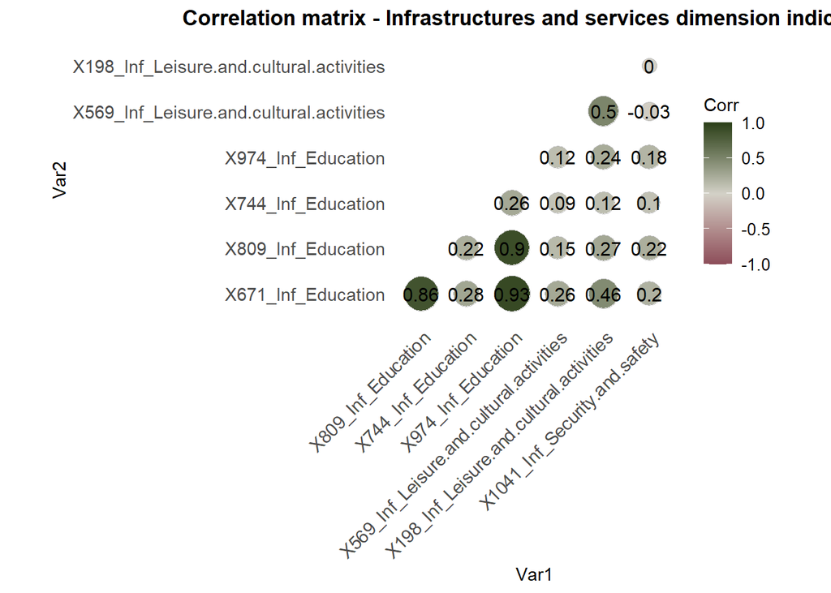

```r
ggcorrplot(cor_matrix_infrastructures,
           method = "circle",
           type = "lower",
           lab = TRUE,
           colors = colors,
           title = "Correlation matrix - Infrastructures and services dimension indicators") +
  theme_minimal(base_family = "Verdana") +
  theme(text = element_text(family = "Verdana")) +
  theme(axis.text = element_text(size = 11),
        axis.title = element_text(size = 11),
        plot.title = element_text(size = 13, face = "bold", hjust = 0.5, lineheight = 1.2),
        legend.text = element_text(size = 10),
        legend.title = element_text(size = 11)) +
  theme(axis.text.x = element_text(angle = 45, hjust = 1)) +
  theme(panel.grid = element_blank())
```

```r
ggsave(here("1_PCA", "Results", "Infrastructures", "heatmap_correlations_infrastructures.png"),
       plot = last_plot(), width = 10, height = 8, dpi = 300)
```

### 3.3.1 Infrastructures and services PCA

```r
#calculate principal components
infrastructures_dim_results <- prcomp(infrastructures_indicators, scale = TRUE)

#display principal components
infrastructures_dim_results$rotation
```

```
##                                                PC1         PC2         PC3
## X671_Inf_Education                       0.5402545  0.04545587  0.13431329
## X809_Inf_Education                       0.5057087  0.19965411  0.20161497
## X744_Inf_Education                       0.2117504  0.04658860 -0.67929874
## X974_Inf_Education                       0.5133020  0.22072556  0.22624542
## X569_Inf_Leisure.and.cultural.activities 0.1977354 -0.66878672 -0.16785309
## X198_Inf_Leisure.and.cultural.activities 0.2877960 -0.58338885 -0.06958276
## X1041_Inf_Security.and.safety            0.1487977  0.34577956 -0.62901602
##                                                    PC4         PC5          PC6
## X671_Inf_Education                        0.0006582244  0.05533127  0.464124758
## X809_Inf_Education                        0.0161062704 -0.10968815 -0.800928666
## X744_Inf_Education                       -0.6992585536  0.02391501 -0.044056875
## X974_Inf_Education                       -0.0676871414 -0.10447841  0.361727142
## X569_Inf_Leisure.and.cultural.activities  0.1550056752 -0.67858750  0.008247098
## X198_Inf_Leisure.and.cultural.activities  0.1484663280  0.71603742 -0.097094133
## X1041_Inf_Security.and.safety             0.6783266698  0.01512346  0.028612272
##                                                   PC7
## X671_Inf_Education                        0.685233530
## X809_Inf_Education                        0.099853518
## X744_Inf_Education                       -0.008308239
## X974_Inf_Education                       -0.700193151
## X569_Inf_Leisure.and.cultural.activities -0.029573667
## X198_Inf_Leisure.and.cultural.activities -0.166763483
## X1041_Inf_Security.and.safety            -0.038211880
```

```r
write.csv(infrastructures_dim_results$rotation,
          file = here("1_PCA", "Results", "Infrastructures", "infrastructures_pca.csv"),
          row.names = TRUE)
```

```r
var_exp_infrastructures_dim <- infrastructures_dim_results$sdev^2 / sum(infrastructures_dim_results$sdev^2)

var_exp_infrastructures_dim * 100
```

```
## [1] 45.6915217 19.2879718 13.0842040 12.5772275  6.9508769  1.8826049  0.5255932
```

```r
png(here("1_PCA", "Results", "Infrastructures", "scree_plot_pca_infrastructures_dimension.png"),
    width = 800, height = 600, res = 150)

par(family = "Verdana")

plot(var_exp_infrastructures_dim * 100, type = "b", xlab = "Principal Component",
     ylab = "Variance explained (%)", main = "Scree plot PCA Infrastructures and services dimension",
     col = "black", lwd = 1, pch = 16)

points(1:2, var_exp_infrastructures_dim[1:2] * 100, col = col, pch = 16, cex = 1.5)
lines(1:2, var_exp_infrastructures_dim[1:2] * 100, col = col, lwd = 3)

dev.off()
```

### 3.3.2 Infrastructures and services weight

In this case and because of the complexity of numerous indicators, 3 PC are used to retain as much variance as possible.

```r
# Calculate combined weights of PC1, Pc2 and Pc3

# Absolute values for PC1
weight_PC1_infrastructuresdim <- abs(infrastructures_dim_results$rotation[, 1])
# Absolute values for PC2
weight_PC2_infrastructuresdim <- abs(infrastructures_dim_results$rotation[, 2])
# Absolute values for PC3
weight_PC3_infrastructuresdim <- abs(infrastructures_dim_results$rotation[, 3])

# Ponderated according to explicit variance
variance_PC1 <- var_exp_infrastructures_dim[1]
variance_PC2 <- var_exp_infrastructures_dim[2]
variance_PC3 <- var_exp_infrastructures_dim[3]

# Calculation of the weighted contribution for each indicator
combined_weight_infrastructuresdim <- (weight_PC1_infrastructuresdim * variance_PC1 +
                                  weight_PC2_infrastructuresdim * variance_PC2 +
                                  weight_PC3_infrastructuresdim * variance_PC3)

# Normalise weights so they sum 1
normalised_pc1_weights_infrastructures <- combined_weight_infrastructuresdim / sum(combined_weight_infrastructuresdim)

# Show normalised weights
normalised_pc1_weights_infrastructures
```

```
##                       X671_Inf_Education
##                                0.1533155
##                       X809_Inf_Education
##                                0.1660902
##                       X744_Inf_Education
##                                0.1092203
##                       X974_Inf_Education
##                                0.1721267
## X569_Inf_Leisure.and.cultural.activities
##                                0.1354211
## X198_Inf_Leisure.and.cultural.activities
##                                0.1420549
##            X1041_Inf_Security.and.safety
##                                0.1217713
```

```r
write.csv(normalised_pc1_weights_infrastructures,
          file = here("1_PCA", "Results", "Infrastructures", "infrastructures_pc1_weights.csv"),
          row.names = TRUE)
```

## 3.4 Healthcare Dimension

```r
healthcare_indicators <- inverted_indicators[, c("X10_Healthcare" ,"X642_Healthcare",
"X257_Healthcare",
"X902_Healthcare"
)]

summary(healthcare_indicators)
```

```
##  X10_Healthcare  X642_Healthcare  X257_Healthcare X902_Healthcare
##  Min.   :77.94   Min.   : 0.000   Min.   : 0.00   Min.   : 0.600
##  1st Qu.:83.95   1st Qu.: 0.000   1st Qu.: 7.00   1st Qu.: 2.300
##  Median :84.88   Median : 1.000   Median :13.00   Median : 3.100
##  Mean   :84.38   Mean   : 1.918   Mean   :15.53   Mean   : 3.677
##  3rd Qu.:85.36   3rd Qu.: 3.000   3rd Qu.:20.00   3rd Qu.: 4.400
##  Max.   :87.62   Max.   :10.000   Max.   :63.00   Max.   :10.300
```

```r
cor_matrix_healthcare <- cor(healthcare_indicators)
print(cor_matrix_healthcare)
```

```
##                 X10_Healthcare X642_Healthcare X257_Healthcare X902_Healthcare
## X10_Healthcare       1.0000000       0.1671926       0.2763579      -0.6416438
## X642_Healthcare      0.1671926       1.0000000       0.5622868      -0.2854516
## X257_Healthcare      0.2763579       0.5622868       1.0000000      -0.3744797
## X902_Healthcare     -0.6416438      -0.2854516      -0.3744797       1.0000000
```

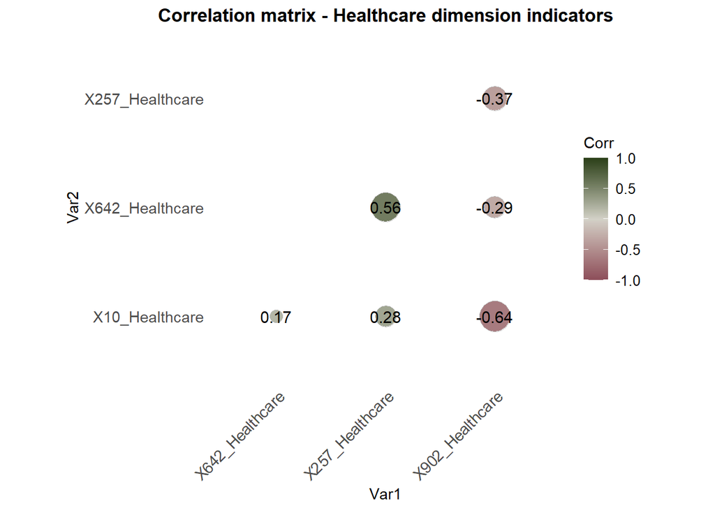

```r
ggcorrplot(cor_matrix_healthcare,
           method = "circle",
           type = "lower",

           lab = TRUE,
           colors = colors,
           title = "Correlation matrix - Healthcare dimension indicators") +
  theme_minimal(base_family = "Verdana") +
  theme(text = element_text(family = "Verdana")) +
  theme(axis.text = element_text(size = 11),
        axis.title = element_text(size = 11),
        plot.title = element_text(size = 13, face = "bold", hjust = 0.5, lineheight = 1.2),
        legend.text = element_text(size = 10),
        legend.title = element_text(size = 11)) +
  theme(axis.text.x = element_text(angle = 45, hjust = 1)) +
  theme(panel.grid = element_blank())
```

```r
ggsave(here("1_PCA", "Results", "Healthcare", "heatmap_correlations_healthcare.png"),
       plot = last_plot(), width = 10, height = 8, dpi = 300)
```

### 3.4.1 Healthcare PCA

```r
#calculate principal components
healthcare_dim_results <- prcomp(healthcare_indicators, scale = TRUE)

#display principal components
healthcare_dim_results$rotation
```

```
##                        PC1        PC2         PC3         PC4
## X10_Healthcare   0.4878649  0.5553751  0.03686111 -0.67244895
## X642_Healthcare  0.4515653 -0.5875689  0.66037788 -0.12146051
## X257_Healthcare  0.5106346 -0.4346568 -0.74126657 -0.02914833
## X902_Healthcare -0.5452787 -0.3967301 -0.11430739 -0.72952734
```

```r
write.csv(healthcare_dim_results$rotation,
          file = here("1_PCA", "Results", "Healthcare", "healthcare_pca.csv"),
          row.names = TRUE)
```

```r
var_exp_healthcare_dim <- healthcare_dim_results$sdev^2 / sum(healthcare_dim_results$sdev^2)

var_exp_healthcare_dim * 100
```

```
## [1] 54.02909 26.62959 10.68955  8.65177
```

```r
png(here("1_PCA", "Results", "Healthcare", "scree_plot_pca_healthcare_dimension.png"),
    width = 800, height = 600, res = 150)

par(family = "Verdana")

plot(var_exp_healthcare_dim * 100, type = "b", xlab = "Principal Component",
     ylab = "Variance explained (%)", main = "Scree plot PCA Healthcare dimension",
     col = "black", lwd = 1, pch = 16)

points(1:2, var_exp_healthcare_dim[1:2] * 100, col = col, pch = 16, cex = 1.5)
lines(1:2, var_exp_healthcare_dim[1:2] * 100, col = col, lwd = 3)

dev.off()
```

### 3.4.2 Healthcare weight

Weights are derived from PC1 loadings only and normalised to sum to one.

```r
pc1_weights <- abs(healthcare_dim_results$rotation[, 1])

normalised_pc1_weights_healthcare <- pc1_weights / sum(pc1_weights)

normalised_pc1_weights_healthcare
```

```
##  X10_Healthcare X642_Healthcare X257_Healthcare X902_Healthcare
##       0.2445017       0.2263095       0.2559131       0.2732756
```

```r
write.csv(normalised_pc1_weights_healthcare,
          file = here("1_PCA", "Results", "Healthcare", "healthcare_pc1_weights.csv"),
          row.names = TRUE)
```

## 3.5 Housing and shelter dimension

The Housing and shelter dimension subset includes six indicators (one neutral indicator, X148_Housing, was removed in section 2.2).

```r
housing_indicators <- inverted_indicators[, c("X465_Housing", "X674_Housing","X477_Housing", "X139_Housing","X866_Housing",
"X653_Housing")]

summary(housing_indicators)
```

```
##   X465_Housing    X674_Housing     X477_Housing     X139_Housing
##  Min.   :36.79   Min.   :-21.06   Min.   : 52.00   Min.   :-2.930
##  1st Qu.:58.99   1st Qu.:-16.69   1st Qu.: 64.09   1st Qu.:-2.530
##  Median :63.81   Median :-15.46   Median : 68.81   Median :-2.440
##  Mean   :61.94   Mean   :-14.80   Mean   : 70.89   Mean   :-2.486
##  3rd Qu.:66.97   3rd Qu.:-13.61   3rd Qu.: 74.07   3rd Qu.:-2.390
##  Max.   :83.01   Max.   :  0.00   Max.   :115.03   Max.   :-2.050
##   X866_Housing    X653_Housing
##  Min.   :-5591   Min.   :  0.00
##  1st Qu.:-4052   1st Qu.: 87.72
##  Median :-3170   Median : 92.65
##  Mean   :-3306   Mean   : 89.32
##  3rd Qu.:-2489   3rd Qu.: 95.67
##  Max.   :-1115   Max.   :100.00
```

```r
cor_matrix_housing <- cor(housing_indicators)
print(cor_matrix_housing)
```

```
##              X465_Housing X674_Housing X477_Housing X139_Housing X866_Housing
## X465_Housing   1.00000000   0.04616703  -0.02402508   -0.2493474  0.335871654
## X674_Housing   0.04616703   1.00000000  -0.41289640   -0.2845681  0.723483589
## X477_Housing  -0.02402508  -0.41289640   1.00000000   -0.1854009 -0.673965812
## X139_Housing  -0.24934744  -0.28456814  -0.18540085    1.0000000 -0.290630277
## X866_Housing   0.33587165   0.72348359  -0.67396581   -0.2906303  1.000000000
## X653_Housing   0.55429414   0.00706975   0.21313796   -0.1384742  0.008009163
##              X653_Housing
## X465_Housing  0.554294139
## X674_Housing  0.007069750
## X477_Housing  0.213137957
## X139_Housing -0.138474237
## X866_Housing  0.008009163
## X653_Housing  1.000000000
```

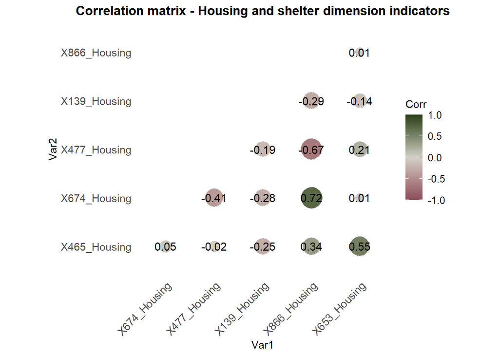

```r
ggcorrplot(cor_matrix_housing,
           method = "circle",
           type = "lower",

           lab = TRUE,
           colors = colors,
           title = "Correlation matrix - Housing and shelter dimension indicators") +
  theme_minimal(base_family = "Verdana") +
  theme(text = element_text(family = "Verdana")) +
  theme(axis.text = element_text(size = 11),
        axis.title = element_text(size = 11),
        plot.title = element_text(size = 13, face = "bold", hjust = 0.5, lineheight = 1.2),
        legend.text = element_text(size = 10),
        legend.title = element_text(size = 11)) +
  theme(axis.text.x = element_text(angle = 45, hjust = 1)) +
  theme(panel.grid = element_blank())
```

```r
ggsave(here("1_PCA", "Results", "Housing", "heatmap_correlations_housing.png"),
       plot = last_plot(), width = 10, height = 8, dpi = 300)
```

### 3.5.1 Housing PCA

```r
housing_dim_results <- prcomp(housing_indicators, scale = TRUE)

#display principal components
housing_dim_results$rotation
```

```
##                      PC1         PC2         PC3        PC4         PC5
## X465_Housing  0.25635299  0.56262101  0.34675420 -0.4586997  0.46179231
## X674_Housing  0.53403661 -0.11096730 -0.24248329  0.5940191  0.39445055
## X477_Housing -0.43948891  0.38967409 -0.40489945  0.2099541  0.52522220
## X139_Housing -0.24299636 -0.35134690  0.74432116  0.2951370  0.38956300
## X866_Housing  0.62633713 -0.06623639  0.03496933 -0.1154041  0.04293615
## X653_Housing  0.06776509  0.62567249  0.31903445  0.5405842 -0.44910514
##                      PC6
## X465_Housing  0.27174378
## X674_Housing  0.36775418
## X477_Housing -0.41366769
## X139_Housing -0.15693622
## X866_Housing -0.76611360
## X653_Housing -0.09073141
```

```r
write.csv(housing_dim_results$rotation,
          file = here("1_PCA", "Results", "Housing", "housing_pca.csv"),
          row.names = TRUE)
```

```r
var_exp_housing_dim <- housing_dim_results$sdev^2 / sum(housing_dim_results$sdev^2)

var_exp_housing_dim * 100
```

```
## [1] 39.014423 28.447307 16.739849  9.048396  4.898759  1.851267
```

```r
png(here("1_PCA", "Results", "Housing", "scree_plot_pca_housing_dimension.png"),
    width = 800, height = 600, res = 150)

par(family = "Verdana")

plot(var_exp_housing_dim * 100, type = "b", xlab = "Principal Component",
     ylab = "Variance explained (%)", main = "Scree plot PCA Housing and shelter dimension",
     col = "black", lwd = 1, pch = 16)

points(1:2, var_exp_housing_dim[1:2] * 100, col = col, pch = 16, cex = 1.5)
lines(1:2, var_exp_housing_dim[1:2] * 100, col = col, lwd = 3)

dev.off()
```

### 3.5.2 Housing weight

As with the economic dimension, PC1 and PC2 are combined for weighting.

```r
weight_PC1_housingdim <- abs(housing_dim_results$rotation[, 1])
normalised_weight_housingdim<- weight_PC1_housingdim / sum(weight_PC1_housingdim)
normalised_weight_housingdim
```

```
## X465_Housing X674_Housing X477_Housing X139_Housing X866_Housing X653_Housing
##   0.11829981   0.24644312   0.20281198   0.11213610   0.28903727   0.03127172
```

```r
weight_PC1_housingdim <- abs(housing_dim_results$rotation[, 1])
weight_PC2_housingdim <- abs(housing_dim_results$rotation[, 2])

variance_PC1 <- var_exp_housing_dim[1]
variance_PC2 <- var_exp_housing_dim[2]

combined_weight_housingdim <- (weight_PC1_housingdim * variance_PC1 +
weight_PC2_housingdim * variance_PC2)

#Normalise weights so that they sum 1
normalised_combined_weight_housingdim <- combined_weight_housingdim / sum(combined_weight_housingdim)

normalised_combined_weight_housingdim
```

```
## X465_Housing X674_Housing X477_Housing X139_Housing X866_Housing X653_Housing
##    0.1800156    0.1660702    0.1954174    0.1348064    0.1821885    0.1415019
```

```r
write.csv(normalised_combined_weight_housingdim,
          file = here("1_PCA", "Results", "Housing", "housing_weight.csv"),
          row.names = TRUE)
```

## 3.6 Mobility and accessibility dimension

The Mobility and accessibility dimension includes three indicators. With only three indicators, the PCA produces three components; PC1 is used for weighting.

```r
mobility_indicators <- inverted_indicators[, c("X989_Mob_", "X361_Mob_", "X515_Mob_")]

summary(mobility_indicators)
```

```
##    X989_Mob_        X361_Mob_         X515_Mob_
##  Min.   :-66.67   Min.   :-8891.5   Min.   :  30
##  1st Qu.:-22.22   1st Qu.: -548.2   1st Qu.: 623
##  Median :-14.67   Median : -463.1   Median :1289
##  Mean   :-18.58   Mean   : -605.9   Mean   :1461
##  3rd Qu.: -9.77   3rd Qu.: -421.3   3rd Qu.:2020
##  Max.   : -3.70   Max.   : -262.1   Max.   :5249
```

```r
cor_matrix_mobility <- cor(mobility_indicators)
print(cor_matrix_mobility)
```

```
##           X989_Mob_ X361_Mob_ X515_Mob_
## X989_Mob_ 1.0000000 0.3715030 0.4041864
## X361_Mob_ 0.3715030 1.0000000 0.1127538
## X515_Mob_ 0.4041864 0.1127538 1.0000000
```

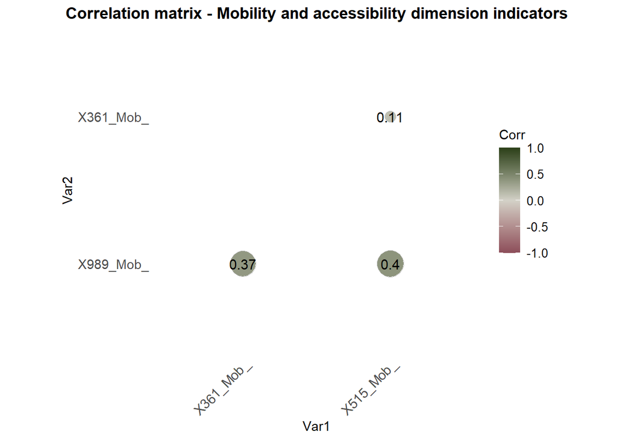

```r
ggcorrplot(cor_matrix_mobility,
           method = "circle",
           type = "lower",

           lab = TRUE,
           colors = colors,
           title = "Correlation matrix - Mobility and accessibility dimension indicators") +
  theme_minimal(base_family = "Verdana") +
  theme(text = element_text(family = "Verdana")) +
  theme(axis.text = element_text(size = 11),
        axis.title = element_text(size = 11),
        plot.title = element_text(size = 13, face = "bold", hjust = 0.5, lineheight = 1.2),
        legend.text = element_text(size = 10),
        legend.title = element_text(size = 11)) +
  theme(axis.text.x = element_text(angle = 45, hjust = 1)) +
  theme(panel.grid = element_blank())
```

```r
ggsave(here("1_PCA", "Results", "Mobility", "heatmap_correlations_mobility.png"),
       plot = last_plot(), width = 10, height = 8, dpi = 300)
```

### 3.6.1 Mobility PCA

```r
#calculate principal components
mobility_dim_results <- prcomp(mobility_indicators, scale = TRUE)

#display principal components
mobility_dim_results$rotation
```

```
##                 PC1         PC2        PC3
## X989_Mob_ 0.6700762 -0.01885247 -0.7420529
## X361_Mob_ 0.5094694  0.73872103  0.4412847
## X515_Mob_ 0.5398507 -0.67374759  0.5046042
```

```r
write.csv(mobility_dim_results$rotation,
          file = here("1_PCA", "Results", "Mobility", "mobility_pca.csv"),
          row.names = TRUE)
```

```r
var_exp_mobility_dim <- mobility_dim_results$sdev^2 / sum(mobility_dim_results$sdev^2)

var_exp_mobility_dim * 100
```

```
## [1] 53.60315 29.58941 16.80743
```

```r
png(here("1_PCA", "Results", "Mobility", "scree_plot_pca_mobility_dimension.png"),
    width = 800, height = 600, res = 150)

par(family = "Verdana")

plot(var_exp_mobility_dim * 100, type = "b", xlab = "Principal Component",
     ylab = "Variance explained (%)", main = "Scree plot PCA Mobility and accessibility dimension",
     col = "black", lwd = 1, pch = 16)

points(1:2, var_exp_mobility_dim[1:2] * 100, col = col, pch = 16, cex = 1.5)
lines(1:2, var_exp_mobility_dim[1:2] * 100, col = col, lwd = 3)

dev.off()
```

### 3.6.2 Mobility weight

```r
pc1_weights <- abs(mobility_dim_results$rotation[, 1])

normalised_pc1_weights_mobility <- pc1_weights / sum(pc1_weights)

normalised_pc1_weights_mobility
```

```
## X989_Mob_ X361_Mob_ X515_Mob_
## 0.3897160 0.2963071 0.3139769
```

```r
write.csv(normalised_pc1_weights_mobility,
          file = here("1_PCA", "Results", "Mobility", "mobility_pc1_weights.csv"),
          row.names = TRUE)
```

## 3.7 Social inclusion Dimension

Following the removal of five neutral indicators in section 2.2, the social inclusion dimension retains three indicators: cultural diversity and identity (X329), public participation and trust in institutions (X799), and social participation (X565). Weights are based on PC1 only.

```r
social_indicators <- inverted_indicators[, c(
"X329_Soc_Cultural.diversity.and.identity",
"X799_Soc_Public.participation.and.trust.in.institutions",
"X565_Soc_Social.participation"
)]

summary(social_indicators)
```

```
##  X329_Soc_Cultural.diversity.and.identity
##  Min.   : 0.00
##  1st Qu.:18.83
##  Median :35.71
##  Mean   :32.68
##  3rd Qu.:45.36
##  Max.   :66.67
##  X799_Soc_Public.participation.and.trust.in.institutions
##  Min.   :-16.44
##  1st Qu.:-12.07
##  Median : -9.59
##  Mean   :-10.65
##  3rd Qu.: -8.71
##  Max.   : -6.65
##  X565_Soc_Social.participation
##  Min.   :  3.00
##  1st Qu.: 26.00
##  Median : 50.00
##  Mean   : 75.97
##  3rd Qu.: 84.00
##  Max.   :360.00
```

```r
cor_matrix_social <- cor(social_indicators)
print(cor_matrix_social)
```

```
##                                                         X329_Soc_Cultural.diversity.and.identity
## X329_Soc_Cultural.diversity.and.identity                                               1.0000000
## X799_Soc_Public.participation.and.trust.in.institutions                                0.7344362
## X565_Soc_Social.participation                                                          0.1957832
##                                                         X799_Soc_Public.participation.and.trust.in.institutions
## X329_Soc_Cultural.diversity.and.identity                                                             0.73443620
## X799_Soc_Public.participation.and.trust.in.institutions                                              1.00000000
## X565_Soc_Social.participation                                                                        0.09660932
##                                                         X565_Soc_Social.participation
## X329_Soc_Cultural.diversity.and.identity                                   0.19578315
## X799_Soc_Public.participation.and.trust.in.institutions                    0.09660932
## X565_Soc_Social.participation                                              1.00000000
```

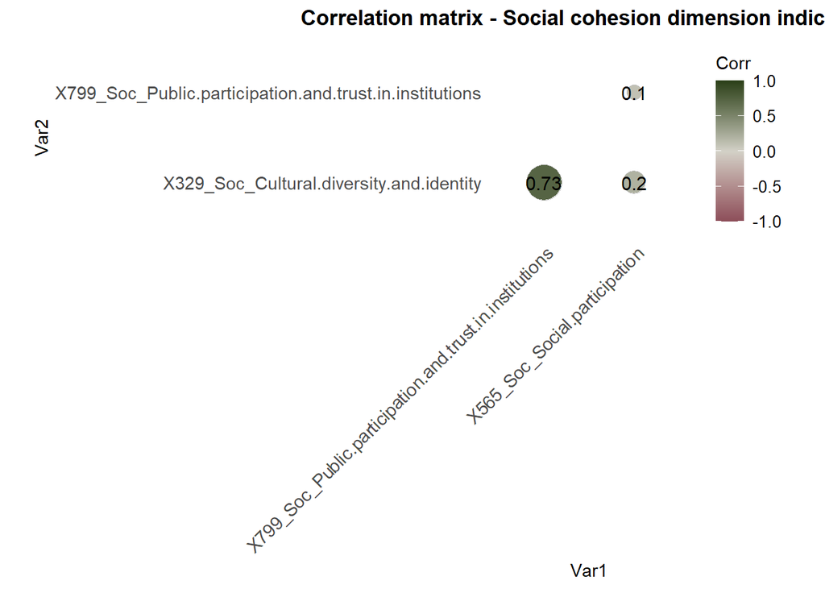

```r
ggcorrplot(cor_matrix_social,
           method = "circle",
           type = "lower",

           lab = TRUE,
           colors = colors,
           title = "Correlation matrix - Social cohesion dimension indicators") +
  theme_minimal(base_family = "Verdana") +
  theme(text = element_text(family = "Verdana")) +
  theme(axis.text = element_text(size = 11),
        axis.title = element_text(size = 11),
        plot.title = element_text(size = 13, face = "bold", hjust = 0.5, lineheight = 1.2),
        legend.text = element_text(size = 10),
        legend.title = element_text(size = 11)) +
  theme(axis.text.x = element_text(angle = 45, hjust = 1)) +
  theme(panel.grid = element_blank())
```

```r
ggsave(here("1_PCA", "Results", "Social", "heatmap_correlations_social.png"),
       plot = last_plot(), width = 10, height = 8, dpi = 300)
```

### 3.7.1 Social inclusion PCA

```r
social_dim_results <- prcomp(social_indicators, scale = TRUE)

social_dim_results$rotation
```

```
##                                                               PC1        PC2
## X329_Soc_Cultural.diversity.and.identity                0.6920600 -0.1104286
## X799_Soc_Public.participation.and.trust.in.institutions 0.6754915 -0.2493301
## X565_Soc_Social.participation                           0.2544882  0.9621019
##                                                                 PC3
## X329_Soc_Cultural.diversity.and.identity                -0.71334318
## X799_Soc_Public.participation.and.trust.in.institutions  0.69393500
## X565_Soc_Social.participation                            0.09795781
```

```r
write.csv(social_dim_results$rotation,
          file = here("1_PCA", "Results", "Social", "social_pca.csv"),
          row.names = TRUE)
```

```r
var_exp_social_dim <- social_dim_results$sdev^2 / sum(social_dim_results$sdev^2)

var_exp_social_dim * 100
```

```
## [1] 59.628255 31.749728  8.622017
```

```r
png(here("1_PCA", "Results", "Social", "scree_plot_pca_social_dimension.png"),
    width = 800, height = 600, res = 150)

par(family = "Verdana")

plot(var_exp_social_dim * 100, type = "b", xlab = "Principal Component",
     ylab = "Variance explained (%)", main = "Scree plot PCA Social cohesion dimension",
     col = "black", lwd = 1, pch = 16)

points(1:2, var_exp_social_dim[1:2] * 100, col = col, pch = 16, cex = 1.5)
lines(1:2, var_exp_social_dim[1:2] * 100, col = col, lwd = 3)

dev.off()
```

### 3.7.2 Social inclusion weight

```r
pc1_weights <- abs(social_dim_results$rotation[, 1])

normalised_pc1_weights_social <- pc1_weights / sum(pc1_weights)

normalised_pc1_weights_social
```

```
##                X329_Soc_Cultural.diversity.and.identity
##                                               0.4266603
## X799_Soc_Public.participation.and.trust.in.institutions
##                                               0.4164457
##                           X565_Soc_Social.participation
##                                               0.1568940
```

```r
write.csv(normalised_pc1_weights_social,
          file = here("1_PCA", "Results", "Social", "social_pc1_weights.csv"),
          row.names = TRUE)
```

#4. Aggregating indicators Once all dimension weights have been calculated, a composite index score is computed for each neighbourhood and dimension. Each indicator is first standardised using z-score normalisation (mean = 0, sd = 1) to allow comparison across different units and scales. The standardised values are then multiplied by their respective weights and summed to produce a single score per dimension per neighbourhood. The seven dimension scores are combined into a single summary table alongside neighbourhood identifiers.

```r
# Extract neighbourhood IDs and names
barrio_info <- inverted_indicators %>%
  select(codi_barri, nom_barri, "Barrio.turístico.en.2023", satisfaction)

# Function to normalise, weight, and aggregate indicators
calculate_dimension_index <- function(indicators, weights) {
  indicators_scaled <- scale(indicators)
  weighted_scores <- indicators_scaled %*% weights
  return(as.numeric(weighted_scores))
}

# Calculate index by dimension
economic_index <- calculate_dimension_index(economic_indicators, normalised_combined_weight_economicdim)
healthcare_index <- calculate_dimension_index(healthcare_indicators, normalised_pc1_weights_healthcare)
housing_index <- calculate_dimension_index(housing_indicators, normalised_combined_weight_housingdim)
infrastructure_index <- calculate_dimension_index(infrastructures_indicators, normalised_pc1_weights_infrastructures)
mobility_index <- calculate_dimension_index(mobility_indicators, normalised_pc1_weights_mobility)
social_index <- calculate_dimension_index(social_indicators, normalised_pc1_weights_social)
urban_index <- calculate_dimension_index(urban_indicators, normalised_combined_weight_urbandim)

# Combine in one table
aggregated_indicators <- barrio_info %>%
  mutate(
    Economic = economic_index,
    Healthcare = healthcare_index,
    Housing = housing_index,
    Infrastructure = infrastructure_index,
    Mobility = mobility_index,
    Social = social_index,
    Urban = urban_index
  )
```

The first rows of the aggregated table are displayed as a preview.

```r
head(aggregated_indicators)
```

|  | codi_barri | nom_barri | Barrio.turístico.en.2023 | satisfaction | Economic | Healthcare | Housing | Infrastructure | Mobility | Social | Urban |
| --- | --- | --- | --- | --- | --- | --- | --- | --- | --- | --- | --- |
| 1 | 1 | el Raval | Yes | 5.88 | -0.46943075 | 0.46586706 | -1.0138480 | -0.20149609 | 0.081912393 | -0.5304780 | 0.4758579 |
| 2 | 2 | el Barri Gòtic | Yes | 6.71 | -0.14231200 | -0.21827077 | -0.4864620 | 0.17487276 | -0.160304877 | -0.8469322 | 0.3765598 |
| 3 | 3 | la Barceloneta | Yes | 7.40 | -0.18169692 | -0.34076389 | -0.7961988 | 0.04792955 | 0.106680625 | -0.9517885 | -0.3734313 |
| 4 | 4 | Sant Pere, Santa Caterina i la Ribera | Yes | 6.53 | 0.21573941 | 0.49643701 | -0.6478019 | 0.84150942 | 0.007987994 | -0.5459803 | 0.6347651 |
| 5 | 6 | la Sagrada Família | Yes | 7.60 | 0.02584574 | 0.09566967 | -0.2203509 | 1.25261013 | 1.053773129 | 0.5606871 | 0.2610239 |
| 6 | 10 | Sant Antoni | Yes | 7.77 | 0.26131538 | 0.25622133 | -0.1653692 | 0.53754322 | 0.726660894 | 0.5080799 | 0.1277511 |

The final table is saved as a CSV file for use in subsequent analyses.

```r
write.csv2(aggregated_indicators,
           file = here("1_PCA", "Results", "Aggregated", "aggregated_indicators_by_neighbourhood.csv"),
           row.names = FALSE,
           quote = TRUE)
```

````r
# Capture session information to document the computational environment
session <- sessionInfo()

# Extract package names and versions from loaded packages
pkg_info <- sapply(session$otherPkgs, function(p) {
  paste0("- ", p$Package, " (", p$Version, ")")
})

# Build README content
readme_lines <- c(
  "# UQoL Indicators in Barcelona 2025 - PCA",
  "",
  "## Overview",
  "This repository contains the R Notebook used to compute Principal Component Analysis (PCA) weights and composite UQoL dimension indices for Barcelona neighbourhoods. The analysis is part of a PhD dissertation examining the relationship between tourism impacts and urban quality of life.",
  "",
  "## Repository structure",
  "```",
  "├── UQoL_PCA_Barcelona.Rmd              # This notebook",
  "├── Indicators PCA_Neighbourhood data.csv  # Input data (required)",
  "└── Results/                            # Created automatically on first run",
  "    ├── Economic/",
  "    ├── Healthcare/",
  "    ├── Housing/",
  "    ├── Infrastructures/",
  "    ├── Mobility/",
  "    ├── Social/",
  "    ├── Urban/",
  "    └── Aggregated/",
  "```",
  "",
  "## How to run",
  "1. Place this notebook and `Indicators PCA_Neighbourhood data.csv` in the same directory.",
  "2. Open the notebook in RStudio.",
  "3. Run all chunks in order (Ctrl+Alt+R / Cmd+Alt+R).",
  "4. All outputs are saved automatically under `Results/`.",
  "",
  "## Requirements",
  paste0("- R version: ",
         paste(session$R.version$major, session$R.version$minor, sep = ".")),
  "- The following packages are installed and loaded automatically if missing:",
  "",
  paste(sort(pkg_info), collapse = "\n"),
  "",
  "## Computational environment",
  paste0("- Platform: ", session$platform),
  paste0("- Operating system: ", session$running),
  paste0("- README generated: ", format(Sys.time(), "%Y-%m-%d %H:%M:%S")),
  "",
  "## Citation",
  "If you use or adapt this code, please cite the associated dissertation:",
  "[Author, Year, Title, Institution — to be completed before submission]"
)

# Write to README.md in the project root
writeLines(readme_lines, here("1_PCA", "README.md"))

cat("README.md created successfully.\n")
````

```
## README.md created successfully.
```